# Introducción a la programación y análisis de datos en R

Día 3 · Bloque 1 — pivot_longer(), pivot_wider(), describe()

Filip Andras

CIMCYC — Universidad de Granada

23 octubre 2026

## Mapa del día 3

Bloque 1  
9:00 – 10:30

Datos anchos y largos

De ancho a largo: `pivot_longer()`

Ej. 1

De largo a ancho: `pivot_wider()`

Ej. 2

Tip: descriptivos de golpe

Bloque 2  
11:00 – 12:30

La fórmula en R: `VD ~ VI`

Correlación: `cor.test()`

Ej. 3

Comparar dos grupos: `t.test()`

Ej. 4

Bloque 3  
13:00 – 14:00 · 60’

ANOVA: Fisher y la *F*

ANOVA de una vía: `aov_car()`

Ej. 5

ANOVA mixto: interacción

## El paquete de este bloque: `tidyr`

[figure not shown]

[`readr`](https://rstudio.github.io/cheatsheets/html/data-import.html)Importar archivos (CSV, TSV, etc.)

[`ggplot2`](https://rstudio.github.io/cheatsheets/html/data-visualization.html)Visualización de datos (gráficos)

[`forcats`](https://rstudio.github.io/cheatsheets/html/factors.html)Trabajar con factores (variables categóricas)

[`tidyr`](https://rstudio.github.io/cheatsheets/html/tidyr.html)Reestructurar datos (pivotar, separar, unir)

[`tibble`](https://tibble.tidyverse.org/)Data frames mejorados

[`dplyr`](https://rstudio.github.io/cheatsheets/html/data-transformation.html)Manipulación de datos (filtrar, seleccionar, transformar)

[`stringr`](https://rstudio.github.io/cheatsheets/html/strings.html)Manipulación de texto

[`purrr`](https://rstudio.github.io/cheatsheets/html/purrr.html)Programación funcional (iteración)

Haz clic en `tidyr` para abrir su chuleta oficial (*cheatsheet*).

# Datos anchos y largos

## Dos formas de organizar los mismos datos

[figure not shown]

**Formato ancho** (wide)

[figure not shown]

**Formato largo** (long)

## Ejemplo: los mismos datos en dos formatos

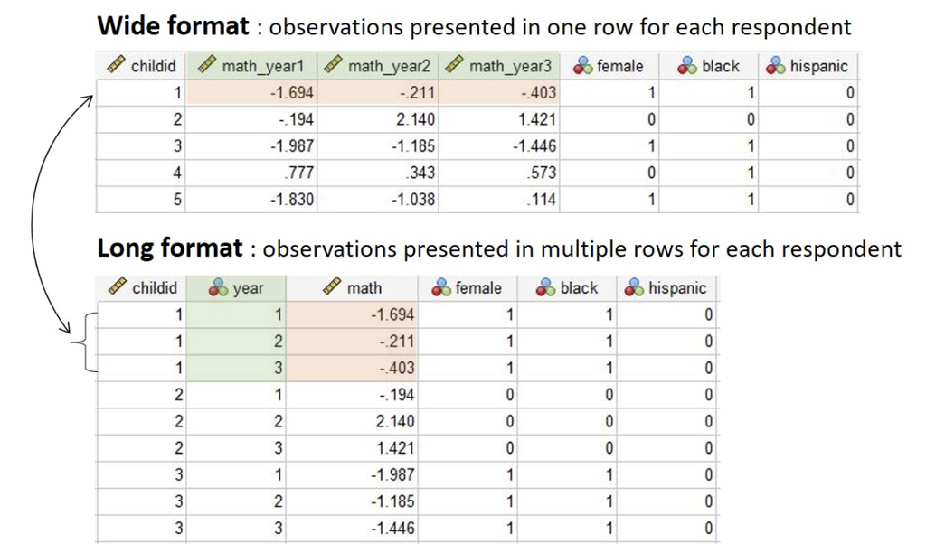

## ¿Alguien de vosotros/as está trabajando con datos longitudinales o medidas repetidas?

## ¿Por qué nos importa el formato?

**Formato largo** (una fila por observación)

- ANOVA de medidas repetidas
- Modelos mixtos / multinivel
- Visualización con ggplot2

**Formato ancho** (una fila por participante)

- t-test pareado
- Correlación entre pre y post
- Calcular diferencias (`pre - post`)
- Análisis multivariados, SEM
- Tablas comparativas legibles

Por ejemplo, una tabla comparativa (una fila por grupo, una columna por momento):

Media de ansiedad por grupo de tratamiento

| Grupo | Ansiedad pre | Ansiedad post | Mejora |
| --- | --- | --- | --- |
| CBT | 15.1 | 10.8 | 4.3 |
| pharmacological | 15.7 | 12.7 | 3.0 |
| control | 15.7 | 15.2 | 0.5 |

## ¿Cómo pasamos de uno a otro?

## Toy example: generamos un mini dataset en formato ancho

```r
# formato ancho: una fila por paciente, una columna por momento de medicion
ancho <- tibble(
  paciente  = 1:4,
  vd_pre  = c(14, 11, 17,  9),
  vd_post = c( 8,  7, 11,  5)
)
ancho
```

```
# A tibble: 4 x 3
  paciente vd_pre vd_post
     <int>  <dbl>   <dbl>
1        1     14       8
2        2     11       7
3        3     17      11
4        4      9       5
```

# De ancho a largo: `pivot_longer()`

## `pivot_longer()` — idea visual

Antes (ancho)

| paciente | vd_pre | vd_post |
| --- | --- | --- |
| 1 | 14 | 8 |
| 2 | 11 | 7 |
| 3 | 17 | 11 |
| 4 | 9 | 5 |

4 filas · 3 columnas

→

Después (largo)

| paciente | momento | vd |
| --- | --- | --- |
| 1 | vd_pre | 14 |
| 1 | vd_post | 8 |
| 2 | vd_pre | 11 |
| 2 | vd_post | 7 |
| 3 | vd_pre | 17 |
| 3 | vd_post | 11 |
| 4 | vd_pre | 9 |
| 4 | vd_post | 5 |

8 filas · 3 columnas

**Importante**

La clave: los **nombres de las columnas** (`vd_pre`, `vd_post`) se convierten en **valores** de una nueva columna (`momento`). Y los números que estaban dentro se apilan en otra columna (`vd`).

data |>

pivot_longer(

cols = <columnas a apilar>,

→ ¿qué columnas quiero convertir en filas?

names_to = "<nombre_etiqueta>",

→ ¿cómo llamo a la columna de etiquetas?

values_to = "<nombre_valor>"

→ ¿cómo llamo a la columna de valores?

)

## `pivot_longer()` — de ancho a largo

```r
# convertir de ancho a largo
largo <- ancho |>
  pivot_longer(
    cols      = c(vd_pre, vd_post),  # columnas que queremos apilar
    names_to  = "momento",               # nombre de la nueva columna de etiquetas
    values_to = "vd"                   # nombre de la nueva columna de valores
  )
largo
```

```
# A tibble: 8 x 3
  paciente momento    vd
     <int> <chr>   <dbl>
1        1 vd_pre     14
2        1 vd_post     8
3        2 vd_pre     11
4        2 vd_post     7
5        3 vd_pre     17
6        3 vd_post    11
7        4 vd_pre      9
8        4 vd_post     5
```

## Preparamos datos de nuestro ensayo

```r
# tabla ancha: una fila por paciente
trial_ancho <- data_trial |>
  select(patient_id, group, anxiety_pre, anxiety_post) |>
  slice_head(n = 8)    # mostrar solo 8 filas para claridad
trial_ancho
```

```
# A tibble: 8 x 4
  patient_id group anxiety_pre anxiety_post
       <dbl> <chr>       <dbl>        <dbl>
1          1 CBT          20           16.6
2          2 CBT          17.7         12.3
3          3 CBT          15.5         11
4          4 CBT          15.9         11.4
5          5 CBT          12.7          9.1
6          6 CBT          14.3          8.4
7          7 CBT          14.3         11.2
8          8 CBT          10            5.9
```

## `pivot_longer()` — creamos el formato largo

```r
# de ancho (anxiety_pre, anxiety_post)
# a largo (una fila por medición)
trial_ancho |>
  pivot_longer(
    cols      = c(anxiety_pre,
                  anxiety_post),
    names_to  = "momento",
    values_to = "anxiety"
  )
```

```
# A tibble: 16 x 4
   patient_id group momento      anxiety
        <dbl> <chr> <chr>          <dbl>
 1          1 CBT   anxiety_pre     20
 2          1 CBT   anxiety_post    16.6
 3          2 CBT   anxiety_pre     17.7
 4          2 CBT   anxiety_post    12.3
 5          3 CBT   anxiety_pre     15.5
 6          3 CBT   anxiety_post    11
 7          4 CBT   anxiety_pre     15.9
 8          4 CBT   anxiety_post    11.4
 9          5 CBT   anxiety_pre     12.7
10          5 CBT   anxiety_post     9.1
11          6 CBT   anxiety_pre     14.3
12          6 CBT   anxiety_post     8.4
13          7 CBT   anxiety_pre     14.3
14          7 CBT   anxiety_post    11.2
15          8 CBT   anxiety_pre     10
16          8 CBT   anxiety_post     5.9
```

## Ejercicio 1 — tu primer `pivot_longer()`

Tiempo: 5 minutos

Tienes este tibble en formato ancho:

```r
datos_ancho <- tibble::tibble(
  paciente = 1:3,
  dia_1    = c(10, 8, 12),
  dia_2    = c(7, 6, 9),
  dia_3    = c(5, 4, 7)
)
```

1. Usa `pivot_longer()` para convertirlo a formato largo, donde las columnas `dia_*` se apilen en una sola columna llamada `dia` y los valores en una columna llamada `puntuacion`.
2. ¿Cuántas filas tiene el resultado?

# De largo a ancho: `pivot_wider()`

## `pivot_wider()` — idea visual

Antes (largo)

| paciente | momento | vd |
| --- | --- | --- |
| 1 | vd_pre | 14 |
| 1 | vd_post | 8 |
| 2 | vd_pre | 11 |
| 2 | vd_post | 7 |
| 3 | vd_pre | 17 |
| 3 | vd_post | 11 |
| 4 | vd_pre | 9 |
| 4 | vd_post | 5 |

8 filas · 3 columnas

→

Después (ancho)

| paciente | vd_pre | vd_post |
| --- | --- | --- |
| 1 | 14 | 8 |
| 2 | 11 | 7 |
| 3 | 17 | 11 |
| 4 | 9 | 5 |

4 filas · 3 columnas

**Nota**

Los valores únicos de `names_from` (aquí: “vd_pre”, “vd_post”) se convierten en **nuevas columnas**. Es la operación inversa de `pivot_longer()`.

data |>

pivot_wider(

names_from = "<columna_etiquetas>",

→ ¿qué columna contiene los nombres nuevos?

values_from = "<columna_valores>"

→ ¿qué columna contiene los valores?

)

## `pivot_wider()` — de largo a ancho

```r
# convertir de largo a ancho
largo |>
  pivot_wider(
    names_from  = "momento",  # columna cuyos valores se convierten en nombres
    values_from = "vd"      # columna cuyos valores rellenan las celdas
  )
```

```
# A tibble: 4 x 3
  paciente vd_pre vd_post
     <int>  <dbl>   <dbl>
1        1     14       8
2        2     11       7
3        3     17      11
4        4      9       5
```

# Ejercicio

## Ejercicio 2 — reestructurar datos de bienestar con seguimiento

Tiempo: 20 minutos

# Tip: descriptivos de golpe

## `psych::describe()` — descriptivos completos en una línea

```r
# instalar si es necesario: install.packages("psych")
# descriptivos completos de una variable
descriptivos_post <- describe(x = data_trial$anxiety_post)
descriptivos_post
```

```
   vars   n  mean   sd median trimmed  mad min  max range  skew kurtosis   se
X1    1 300 12.89 3.23   12.8   12.88 3.11 3.9 20.5  16.6 -0.01    -0.37 0.19
```

**Tip**

Mucho más completo que `summary()`. Las columnas:

- **trimmed** — media recortada al 10% (elimina valores extremos)
- **mad** — desviación absoluta mediana (medida robusta de dispersión)
- **skew** — asimetría: 0 = simétrica, positiva = cola a la derecha, negativa = cola a la izquierda
- **kurtosis** — curtosis: 0 = normal, positiva = colas pesadas, negativa = colas ligeras
- **se** — error estándar de la media

## `describe()` aplicado a varias columnas

```r
# descriptivos de todas las variables numericas a la vez (menos el identificador)
descriptivos_trial <- data_trial |>
  select(where(is.numeric), -patient_id) |>
  describe()
descriptivos_trial
```

## `describe()` aplicado a varias columnas

```
                vars   n  mean    sd median trimmed   mad  min  max range  skew kurtosis   se
age                1 300 41.89 11.14  42.00   41.73 11.86 20.0 70.0  50.0  0.16    -0.47 0.64
n_sessions         2 100 11.73  3.02  12.00   11.82  2.97  4.0 19.0  15.0 -0.25    -0.52 0.30
anxiety_pre        3 300 15.49  2.17  15.35   15.47  2.00 10.0 21.0  11.0  0.13    -0.12 0.13
anxiety_post       4 300 12.89  3.23  12.80   12.88  3.11  3.9 20.5  16.6 -0.01    -0.37 0.19
depression_pre     5 300 14.93  2.95  15.00   14.89  3.26 10.0 23.9  13.9  0.24    -0.38 0.17
depression_post    6 300 11.85  4.64  11.70   11.78  4.89  0.0 23.4  23.4  0.11    -0.50 0.27
wellbeing_pre      7 300 51.00 14.62  51.25   50.85 14.16 15.0 95.0  80.0  0.09     0.02 0.84
wellbeing_post     8 300 55.33 15.39  55.25   55.25 13.86 17.1 95.0  77.9  0.06     0.02 0.89
ucla_pre           9 300 24.67  5.84  25.00   24.61  5.93 10.0 40.0  30.0  0.04    -0.24 0.34
ucla_post         10 300 22.93  6.60  23.00   22.85  7.41 10.0 39.0  29.0  0.10    -0.66 0.38
rosenberg_pre     11 300 25.23  5.69  25.00   25.24  5.93 10.0 40.0  30.0 -0.02     0.15 0.33
rosenberg_post    12 300 26.95  6.55  27.00   27.15  7.41 10.0 40.0  30.0 -0.27    -0.25 0.38
```

## Resumen del bloque 1

Datos anchos y largos

`formato ancho``formato largo``tibble()`

De ancho a largo: `pivot_longer()`

`pivot_longer()``cols =``names_to =``values_to =``starts_with()`

De largo a ancho: `pivot_wider()`

`pivot_wider()``names_from =``values_from =`

Tip: descriptivos de golpe

`describe()`

Con borde naranja: funciones **nuevas** de este bloque.